# My Markdown Primer

Max De Cuba

2025-11-14

## R Markdown

R Markdown is a format that lets me combine regular text, code, and the results of that code in a single document. It helps create reports that are both readable and reproducible, since the analysis and its explanation stay together. This file illustrates a few of the basic features.

Working in R Markdown feels different from writing a normal report, mostly because I can run code and immediately show what it produced. This helps prevent small mistakes or outdated screenshots since the final knitted document always reflects the latest results.

You can write math inline, such as $\alpha + \beta = \gamma$.

You can also display equations on their own line:

$$y = \beta_0 + \beta_1 x$$

## Working With R Code

Below is a simple R code chunk that loads a dataset and shows summary statistics.

```r
summary(cars)
```

```
##      speed           dist
##  Min.   : 4.0   Min.   :  2.00
##  1st Qu.:12.0   1st Qu.: 26.00
##  Median :15.0   Median : 36.00
##  Mean   :15.4   Mean   : 42.98
##  3rd Qu.:19.0   3rd Qu.: 56.00
##  Max.   :25.0   Max.   :120.00
```

## A Simple Plot

The next chunk uses ggplot2 to produce a scatterplot from the mtcars dataset. This version uses your preferred formatting and keeps the structure simple.

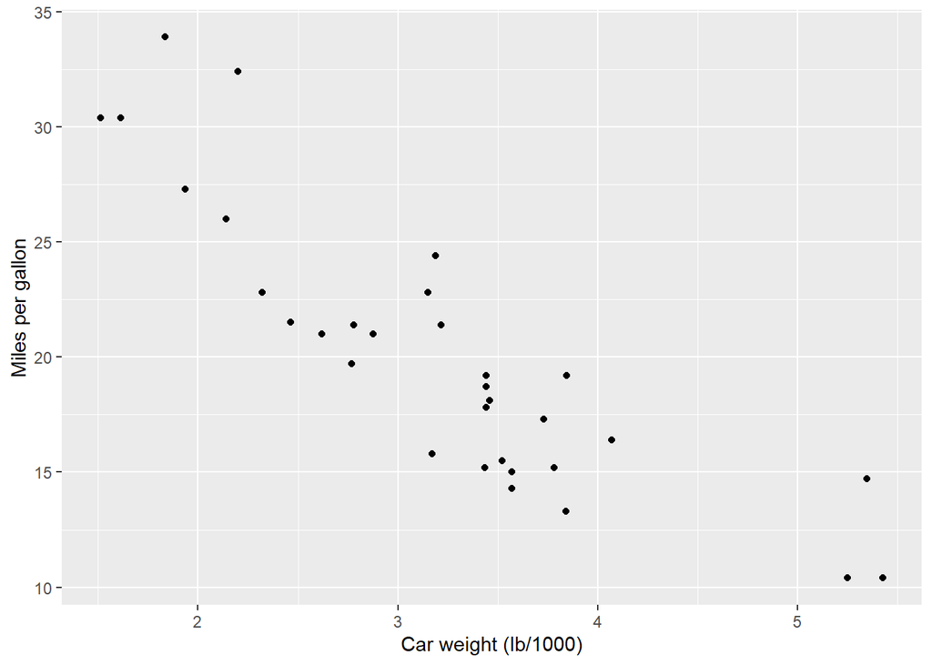

```r
library(ggplot2)
ggplot(mtcars, aes(wt, mpg)) +
geom_point() +
xlab("Car weight (lb/1000)") +
ylab("Miles per gallon")
```

## Conclusion

Using R Markdown helped me keep the explanation and the analysis in the same place, which made the process more organized. Compared to writing a plain report, this approach reduces the chance of mismatched numbers or outdated charts, since everything is generated when I knit the file.